# Manuscript

Kalyn Dorheim

10/25/2022

# 1 Obejective

Visualize and crunch the numbers used to generate figures for the Hector V3 manuscript.

# 2 Set Up

```r
library(assertthat)
library(data.table)
library(dplyr)
library(ggplot2)
library(tidyr)
library(readr)
library(readxl)
library(hector)
hector_version <- packageVersion("hector")
assertthat::assert_that(hector_version == "3.1.1")
```

```
## [1] TRUE
```

```r
# TODO check the parameters

# Load some custom helpful functions
source(here::here("R", "0B.functions.R"))

# Set up the relative paths
BASE_DIR  <- here::here()
FIGS_DIR  <- here::here("output", "figures")
INPUT_DIR <- here::here("data")
HECTOR_RSLTS_DIR <- here::here("output", "hector_output")

# Define some overall figure aesthetics
THEME_BASE_SIZE <- 10
theme_set(theme_bw(base_size = THEME_BASE_SIZE) +
            theme(legend.title = element_blank()))
FULL_FIG <- data.frame(width = 7, height = 7)
MANUSCRIPT_FIG <- data.frame(width = 4, height = 3)

COLOR_SCHEME <- c("grey" = "#999999", "col1" = "#56B4E9", "black" = "#000000",
                  "#009E73", "#E69F00", "#F0E442", "#0072B2", "#D55E00", "#CC79A7")
SSP_COLORS <- c("ssp119" = "#00a9cf", "ssp126" = "#003466", "ssp245" = "#f69320",
                "ssp370" = "#df0000", "ssp434" = "#2274ae","ssp460" = "#b0724e",
                "ssp585"= "#980002", "historical" = "#000000", "historical"="#92397a")
OBS_SCHEME <- c("obs" = "grey", "Hector v3" = "#E69F00")
```

## 2.1 Load Hector Results

```r
list.files(HECTOR_RSLTS_DIR, pattern = "ssp", full.names = TRUE) %>%
  lapply(read.csv) %>%
  do.call(what = "rbind") ->
  hector_ssp
```

# 3 Comparison with Observations

## 3.1 Atmospheric CO<sub>2</sub>

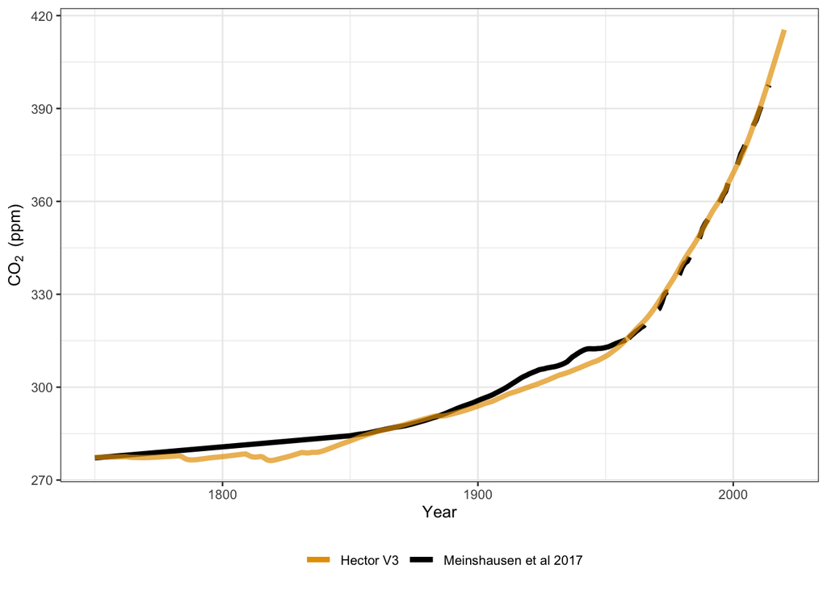

Evaluate historical performance of the model.

RMSE over the full observational period.

```
## [1] 2.212938
```

RMSE excluding the calibration period.

```
## [1] 2.568664
```

Linear regression

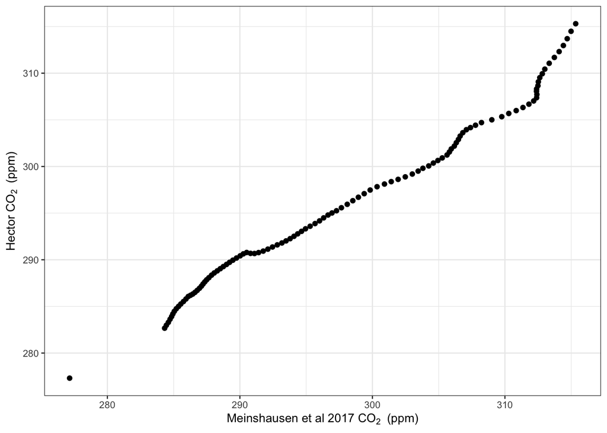

```
##
## Call:
## lm(formula = co2_obs ~ hector_co2, data = wide_data)
##
## Residuals:
##     Min      1Q  Median      3Q     Max
## -4.4415 -0.6989  0.1687  0.8470  1.8205
##
## Coefficients:
##              Estimate Std. Error t value Pr(>|t|)
## (Intercept) -38.17015    3.98576  -9.577 4.28e-16 ***
## hector_co2    1.13526    0.01345  84.419  < 2e-16 ***
## ---
## Signif. codes:  0 '***' 0.001 '**' 0.01 '*' 0.05 '.' 0.1 ' ' 1
##
## Residual standard error: 1.252 on 108 degrees of freedom
## Multiple R-squared:  0.9851, Adjusted R-squared:  0.9849
## F-statistic:  7127 on 1 and 108 DF,  p-value: < 2.2e-16
```

## 3.2 Global Mean Surface Temperature

Mean and SD for the GMST observations

```
## [1] 0.1966327
```

```
## [1] 0.3644875
```

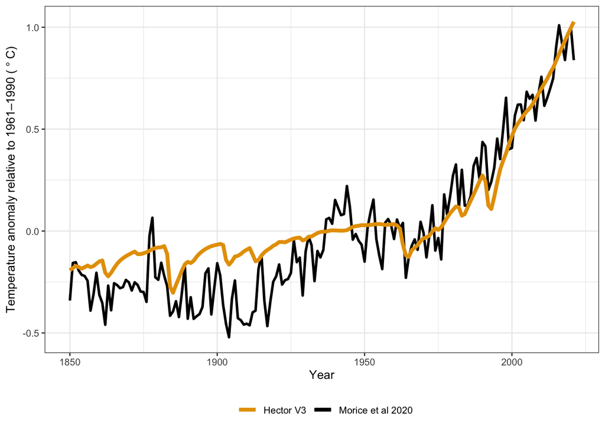

Calcualte RMSE and model-observation fit

```
## [1] 0.1552483
```

Observation - Model fit

```
##
## Call:
## lm(formula = hector_gmst ~ obs, data = gmst_wide)
##
## Residuals:
##      Min       1Q   Median       3Q      Max
## -0.22244 -0.07787 -0.00032  0.06469  0.34308
##
## Coefficients:
##             Estimate Std. Error t value Pr(>|t|)
## (Intercept) 0.063586   0.007994   7.955 2.41e-13 ***
## obs         0.739696   0.021990  33.637  < 2e-16 ***
## ---
## Signif. codes:  0 '***' 0.001 '**' 0.01 '*' 0.05 '.' 0.1 ' ' 1
##
## Residual standard error: 0.1048 on 170 degrees of freedom
## Multiple R-squared:  0.8694, Adjusted R-squared:  0.8686
## F-statistic:  1131 on 1 and 170 DF,  p-value: < 2.2e-16
```

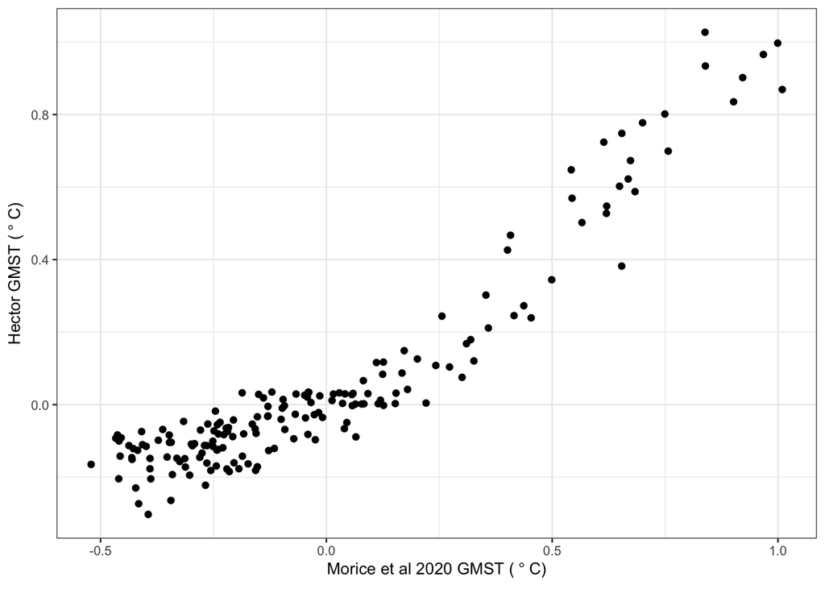

# 4 CMIP6 Comparison

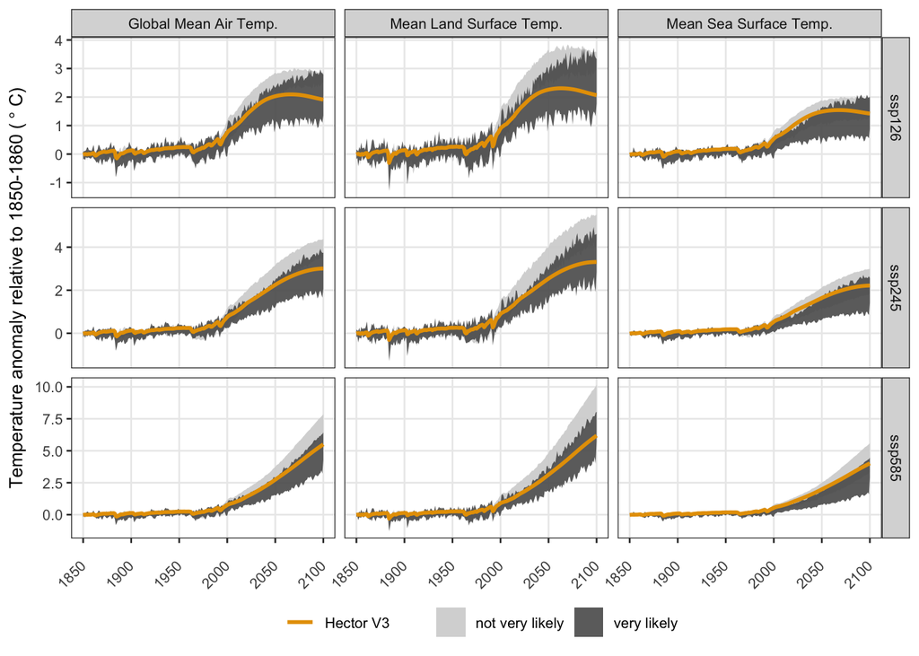

Summary statistics on where the Hector results fall within the stuff

```
## # A tibble: 9 × 2
##   scenario variable
##   <chr>    <chr>
## 1 ssp126   sst
## 2 ssp126   land_tas
## 3 ssp126   global_tas
## 4 ssp245   land_tas
## 5 ssp245   global_tas
## 6 ssp245   sst
## 7 ssp585   land_tas
## 8 ssp585   global_tas
## 9 ssp585   sst
```

# 5 IPCC AR6 comparisons

## 5.1 Recreating IPCC SPM10

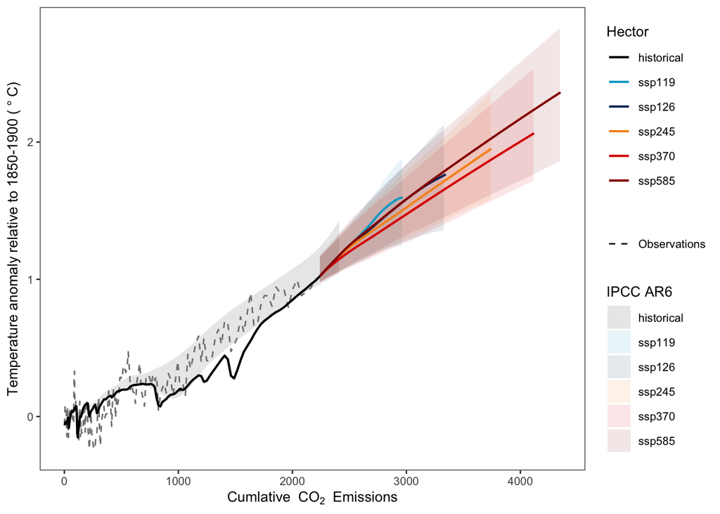

Get information about the TCRE

```
## [1] 2.021294
```

## 5.2 Recreating Table SPM.1

```
## # A tibble: 5 × 4
## # Groups:   scenario [5]
##   scenario `long term` `mid term` `near term`
##   <chr>          <dbl>      <dbl>       <dbl>
## 1 ssp119          1.30       1.50        1.38
## 2 ssp126          1.64       1.68        1.39
## 3 ssp245          2.47       1.88        1.40
## 4 ssp370          3.38       2.01        1.40
## 5 ssp585          4.19       2.31        1.52
```

# 6 Hector’s contemporary state (e.g. magnitude of land and ocean sinks, ocean pH, NPP, etc)

## 6.1 GCP Land Sink

The land CO2 sink continued to increase during the 2012–2021 period primarily in response to increased atmospheric CO2, albeit with large interannual variability. The land CO2 sink was 3.1 ± 0.6 GtC yr−1 during the decade 2012–2021 (29 % of total CO2 emissions), 0.4 GtC yr−1 larger than during the previous decade (2000–2009), with a preliminary 2022 estimate of around 3.4 GtC yr−1.[^1]

```
## # A tibble: 1 × 3
##   variable   mean     sd
##   <chr>     <dbl>  <dbl>
## 1 land sink  1.92 0.0958
```

## 6.2 GCP Ocean Sink

The ocean CO2 sink was 2.9 ± 0.4 GtC yr−1 during the decade 2012–2021 (26 % of total CO2 emissions), with a similar preliminary estimate of 2.9 GtC yr−1 for 2022.[^2]

```
## # A tibble: 1 × 4
## # Groups:   variable [1]
##   variable     units  mean    sd
##   <chr>        <chr> <dbl> <dbl>
## 1 ocean_uptake Pg C   3.07 0.137
```

# 7 ocean pH, & NPP

```
## # A tibble: 1 × 4
## # Groups:   variable [1]
##   variable units  mean      sd
##   <chr>    <chr> <dbl>   <dbl>
## 1 pH       pH     8.10 0.00656
```

```
##       scenario year variable    value units version
## 1       ssp119 2012       pH 8.113909    pH   3.1.1
## 2       ssp119 2013       pH 8.111825    pH   3.1.1
## 3       ssp119 2014       pH 8.109653    pH   3.1.1
## 4       ssp119 2015       pH 8.107430    pH   3.1.1
## 5       ssp119 2016       pH 8.105148    pH   3.1.1
## 6       ssp119 2017       pH 8.103326    pH   3.1.1
## 7       ssp119 2018       pH 8.100495    pH   3.1.1
## 8       ssp119 2019       pH 8.098291    pH   3.1.1
## 9       ssp119 2020       pH 8.096072    pH   3.1.1
## 10      ssp119 2021       pH 8.093848    pH   3.1.1
## 11      ssp126 2012       pH 8.113909    pH   3.1.1
## 12      ssp126 2013       pH 8.111825    pH   3.1.1
## 13      ssp126 2014       pH 8.109653    pH   3.1.1
## 14      ssp126 2015       pH 8.107430    pH   3.1.1
```

[output cut: 66 more lines]

```
## # A tibble: 6 × 4
## # Groups:   variable [6]
##   variable     units     mean      sd
##   <chr>        <chr>    <dbl>   <dbl>
## 1 NPP          Pg C/yr 59.3   0.262
## 2 gmst         degC     0.996 0.0942
## 3 land sink    Pg C/yr  1.92  0.0958
## 4 ocean_uptake Pg C     3.07  0.138
## 5 pH           pH       8.10  0.00684
## 6 sst          degC     0.840 0.0804
```

[^1]: https://essd.copernicus.org/articles/14/4811/2022/
[^2]: https://essd.copernicus.org/articles/14/4811/2022/